# DATA SCIENCE LATAM

UN ESPACIO PARA NUNCA PARAR DE APRENDER!!

Francisco Zambrano Cruz. Mayo 2020.

[figure not shown]

## Guía para implementar LDA (Linear discriminant analysis) con IRIS Data Set

```r
library(DBI)
library(corrgram)
library(caret)
library(gridExtra)
library(ggpubr)
library(reshape2)
library(tidyverse)

## para omitir las advertencias
options( warn = -1 )
```

```r
dataSet <- read.csv("data/iris.data.csv", header = TRUE, sep = ',')
```

```r
head(dataSet)
```

| sepal_length | sepal_width | petal_length | petal_width | Species |
| --- | --- | --- | --- | --- |
| 5.1 | 3.5 | 1.4 | 0.2 | Iris-setosa |
| 4.9 | 3.0 | 1.4 | 0.2 | Iris-setosa |
| 4.7 | 3.2 | 1.3 | 0.2 | Iris-setosa |
| 4.6 | 3.1 | 1.5 | 0.2 | Iris-setosa |
| 5.0 | 3.6 | 1.4 | 0.2 | Iris-setosa |
| 5.4 | 3.9 | 1.7 | 0.4 | Iris-setosa |

```r
tail(dataSet)
```

|  | sepal_length | sepal_width | petal_length | petal_width | Species |
| --- | --- | --- | --- | --- | --- |
| 145 | 6.7 | 3.3 | 5.7 | 2.5 | Iris-virginica |
| 146 | 6.7 | 3.0 | 5.2 | 2.3 | Iris-virginica |
| 147 | 6.3 | 2.5 | 5.0 | 1.9 | Iris-virginica |
| 148 | 6.5 | 3.0 | 5.2 | 2.0 | Iris-virginica |
| 149 | 6.2 | 3.4 | 5.4 | 2.3 | Iris-virginica |
| 150 | 5.9 | 3.0 | 5.1 | 1.8 | Iris-virginica |

```r
# Dimensión del Data set

dim(dataSet)
```

1. 150

2. 5

```r
# Para conocer que tipos de datos son cada variable

table(unlist(lapply(dataSet, class)))
```

```
 factor numeric
      1       4
```

```r
#estructura del Data Set

str(dataSet)
```

```
'data.frame':	150 obs. of  5 variables:
 $ sepal_length: num  5.1 4.9 4.7 4.6 5 5.4 4.6 5 4.4 4.9 ...
 $ sepal_width : num  3.5 3 3.2 3.1 3.6 3.9 3.4 3.4 2.9 3.1 ...
 $ petal_length: num  1.4 1.4 1.3 1.5 1.4 1.7 1.4 1.5 1.4 1.5 ...
 $ petal_width : num  0.2 0.2 0.2 0.2 0.2 0.4 0.3 0.2 0.2 0.1 ...
 $ Species     : Factor w/ 3 levels "Iris-setosa",..: 1 1 1 1 1 1 1 1 1 1 ...
```

```r
# Otra forma de conocer la estructura

glimpse(dataSet)
```

```
Observations: 150
Variables: 5
$ sepal_length <dbl> 5.1, 4.9, 4.7, 4.6, 5.0, 5.4, 4.6, 5.0, 4.4, 4.9, 5.4,...
$ sepal_width  <dbl> 3.5, 3.0, 3.2, 3.1, 3.6, 3.9, 3.4, 3.4, 2.9, 3.1, 3.7,...
$ petal_length <dbl> 1.4, 1.4, 1.3, 1.5, 1.4, 1.7, 1.4, 1.5, 1.4, 1.5, 1.5,...
$ petal_width  <dbl> 0.2, 0.2, 0.2, 0.2, 0.2, 0.4, 0.3, 0.2, 0.2, 0.1, 0.2,...
$ Species      <fct> Iris-setosa, Iris-setosa, Iris-setosa, Iris-setosa, Ir...
```

```r
# Número de datos ausentes por variable

map_dbl(dataSet, .f = function(x){sum(is.na(x))})
```

**sepal_length**

0

**sepal_width**

0

**petal_length**

0

**petal_width**

0

**Species**

0

```r
colSums(is.na(dataSet))
```

**sepal_length**

0

**sepal_width**

0

**petal_length**

0

**petal_width**

0

**Species**

0

```r
#Se procede a identificar qué variables contienen valores “”

dataSet %>% map_lgl(.f = function(x){any(!is.na(x) & x == "")})
```

**sepal_length**

FALSE

**sepal_width**

FALSE

**petal_length**

FALSE

**petal_width**

FALSE

**Species**

FALSE

```r
levels(dataSet$Species)
```

1. 'Iris-setosa'

2. 'Iris-versicolor'

3. 'Iris-virginica'

```r
summary(dataSet)
```

```
  sepal_length    sepal_width     petal_length    petal_width
 Min.   :4.300   Min.   :2.000   Min.   :1.000   Min.   :0.100
 1st Qu.:5.100   1st Qu.:2.800   1st Qu.:1.600   1st Qu.:0.300
 Median :5.800   Median :3.000   Median :4.350   Median :1.300
 Mean   :5.843   Mean   :3.054   Mean   :3.759   Mean   :1.199
 3rd Qu.:6.400   3rd Qu.:3.300   3rd Qu.:5.100   3rd Qu.:1.800
 Max.   :7.900   Max.   :4.400   Max.   :6.900   Max.   :2.500
            Species
 Iris-setosa    :50
 Iris-versicolor:50
 Iris-virginica :50
```

```r
#sapply: cuando desee aplicar una función a cada elemento de una lista,
# pero desea recuperar un vector, en lugar de una lista.

numericalCols <- c('sepal_length', 'sepal_width', 'petal_length', 'petal_width')

sapply(dataSet[numericalCols], FUN = sum)
sapply(dataSet[numericalCols], FUN = mean)
sapply(dataSet[numericalCols], FUN = median)
sapply(dataSet[numericalCols], FUN = min)
sapply(dataSet[numericalCols], FUN = max)
sapply(dataSet[numericalCols], FUN = length)
```

**sepal_length**

876.5

**sepal_width**

458.1

**petal_length**

563.8

**petal_width**

179.8

**sepal_length**

5.84333333333333

**sepal_width**

3.054

**petal_length**

3.75866666666667

**petal_width**

1.19866666666667

**sepal_length**

5.8

**sepal_width**

3

**petal_length**

4.35

**petal_width**

1.3

**sepal_length**

4.3

**sepal_width**

2

**petal_length**

1

**petal_width**

0.1

**sepal_length**

7.9

**sepal_width**

4.4

**petal_length**

6.9

**petal_width**

2.5

**sepal_length**

150

**sepal_width**

150

**petal_length**

150

**petal_width**

150

```r
# Resumen de la variable respuesta

by(dataSet[numericalCols], dataSet[5], FUN = summary)
```

```
Species: Iris-setosa
  sepal_length    sepal_width     petal_length    petal_width
 Min.   :4.300   Min.   :2.300   Min.   :1.000   Min.   :0.100
 1st Qu.:4.800   1st Qu.:3.125   1st Qu.:1.400   1st Qu.:0.200
 Median :5.000   Median :3.400   Median :1.500   Median :0.200
 Mean   :5.006   Mean   :3.418   Mean   :1.464   Mean   :0.244
 3rd Qu.:5.200   3rd Qu.:3.675   3rd Qu.:1.575   3rd Qu.:0.300
 Max.   :5.800   Max.   :4.400   Max.   :1.900   Max.   :0.600
------------------------------------------------------------
Species: Iris-versicolor
  sepal_length    sepal_width     petal_length   petal_width
 Min.   :4.900   Min.   :2.000   Min.   :3.00   Min.   :1.000
 1st Qu.:5.600   1st Qu.:2.525   1st Qu.:4.00   1st Qu.:1.200
 Median :5.900   Median :2.800   Median :4.35   Median :1.300
 Mean   :5.936   Mean   :2.770   Mean   :4.26   Mean   :1.326
 3rd Qu.:6.300   3rd Qu.:3.000   3rd Qu.:4.60   3rd Qu.:1.500
 Max.   :7.000   Max.   :3.400   Max.   :5.10   Max.   :1.800
------------------------------------------------------------
Species: Iris-virginica
  sepal_length    sepal_width     petal_length    petal_width
 Min.   :4.900   Min.   :2.200   Min.   :4.500   Min.   :1.400
 1st Qu.:6.225   1st Qu.:2.800   1st Qu.:5.100   1st Qu.:1.800
 Median :6.500   Median :3.000   Median :5.550   Median :2.000
 Mean   :6.588   Mean   :2.974   Mean   :5.552   Mean   :2.026
 3rd Qu.:6.900   3rd Qu.:3.175   3rd Qu.:5.875   3rd Qu.:2.300
 Max.   :7.900   Max.   :3.800   Max.   :6.900   Max.   :2.500
```

```r
by(dataSet[numericalCols], dataSet$Species, FUN = summary)
```

```
dataSet$Species: Iris-setosa
  sepal_length    sepal_width     petal_length    petal_width
 Min.   :4.300   Min.   :2.300   Min.   :1.000   Min.   :0.100
 1st Qu.:4.800   1st Qu.:3.125   1st Qu.:1.400   1st Qu.:0.200
 Median :5.000   Median :3.400   Median :1.500   Median :0.200
 Mean   :5.006   Mean   :3.418   Mean   :1.464   Mean   :0.244
 3rd Qu.:5.200   3rd Qu.:3.675   3rd Qu.:1.575   3rd Qu.:0.300
 Max.   :5.800   Max.   :4.400   Max.   :1.900   Max.   :0.600
------------------------------------------------------------
dataSet$Species: Iris-versicolor
  sepal_length    sepal_width     petal_length   petal_width
 Min.   :4.900   Min.   :2.000   Min.   :3.00   Min.   :1.000
 1st Qu.:5.600   1st Qu.:2.525   1st Qu.:4.00   1st Qu.:1.200
 Median :5.900   Median :2.800   Median :4.35   Median :1.300
 Mean   :5.936   Mean   :2.770   Mean   :4.26   Mean   :1.326
 3rd Qu.:6.300   3rd Qu.:3.000   3rd Qu.:4.60   3rd Qu.:1.500
 Max.   :7.000   Max.   :3.400   Max.   :5.10   Max.   :1.800
------------------------------------------------------------
dataSet$Species: Iris-virginica
  sepal_length    sepal_width     petal_length    petal_width
 Min.   :4.900   Min.   :2.200   Min.   :4.500   Min.   :1.400
 1st Qu.:6.225   1st Qu.:2.800   1st Qu.:5.100   1st Qu.:1.800
 Median :6.500   Median :3.000   Median :5.550   Median :2.000
 Mean   :6.588   Mean   :2.974   Mean   :5.552   Mean   :2.026
 3rd Qu.:6.900   3rd Qu.:3.175   3rd Qu.:5.875   3rd Qu.:2.300
 Max.   :7.900   Max.   :3.800   Max.   :6.900   Max.   :2.500
```

```r
# Correlations/covariances entre variables numericas
#install.packages("survival")
#install.packages("Hmisc")
library(Hmisc)
```

```r
cor(dataSet[1:4], use="complete.obs", method="kendall")
```

|  | sepal_length | sepal_width | petal_length | petal_width |
| --- | --- | --- | --- | --- |
| sepal_length | 1.00000000 | -0.07211192 | 0.7176238 | 0.6549601 |
| sepal_width | -0.07211192 | 1.00000000 | -0.1823911 | -0.1469880 |
| petal_length | 0.71762378 | -0.18239107 | 1.0000000 | 0.8030139 |
| petal_width | 0.65496014 | -0.14698801 | 0.8030139 | 1.0000000 |

```r
cov(dataSet[1:4], use="complete.obs")
```

|  | sepal_length | sepal_width | petal_length | petal_width |
| --- | --- | --- | --- | --- |
| sepal_length | 0.68569351 | -0.03926846 | 1.2736823 | 0.5169038 |
| sepal_width | -0.03926846 | 0.18800403 | -0.3217128 | -0.1179812 |
| petal_length | 1.27368233 | -0.32171275 | 3.1131794 | 1.2963875 |
| petal_width | 0.51690380 | -0.11798121 | 1.2963875 | 0.5824143 |

```r
rcorr(as.matrix(dataSet[1:4]), type="pearson")
```

```
             sepal_length sepal_width petal_length petal_width
sepal_length         1.00       -0.11         0.87        0.82
sepal_width         -0.11        1.00        -0.42       -0.36
petal_length         0.87       -0.42         1.00        0.96
petal_width          0.82       -0.36         0.96        1.00

n= 150


P
             sepal_length sepal_width petal_length petal_width
sepal_length              0.1828      0.0000       0.0000
sepal_width  0.1828                   0.0000       0.0000
petal_length 0.0000       0.0000                   0.0000
petal_width  0.0000       0.0000      0.0000
```

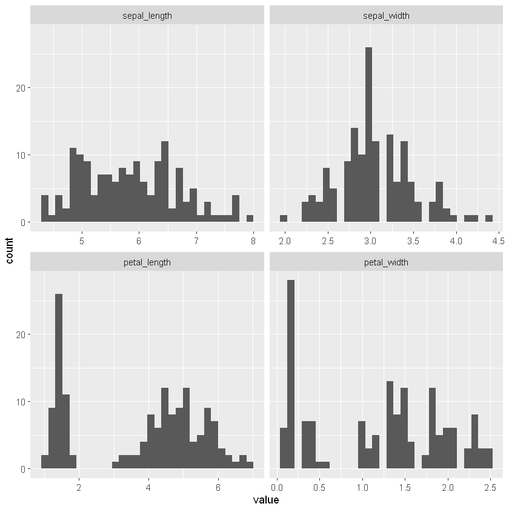

```r
# ----------------------------------------
# Visualizando el DataSet --------------------
# ----------------------------------------

# Histogramas de las variables numericas

ggplot(data = melt(dataSet[1:4]), mapping = aes(x = value)) +
  geom_histogram(bins = 30) +
facet_wrap(~variable, scales = 'free_x')
```

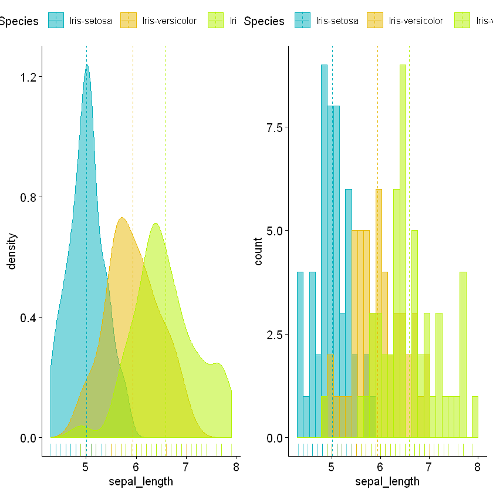

```r
# Graficas de Densidad e Histogramas plots usando ggpubr para la variable "sepal_length"


g1 <- ggdensity(dataSet, x = "sepal_length", add = "mean", rug = TRUE, color = "Species",
                fill = "Species", palette = c("#00AFBB", "#E7B800", "#B3F200"))


g2 <- gghistogram(dataSet, x = "sepal_length", add = "mean", rug = TRUE, color = "Species",
                  fill = "Species", palette = c("#00AFBB", "#E7B800", "#B3F200"))

# grid presentation

grid.arrange(g1, g2, nrow = 1)
```

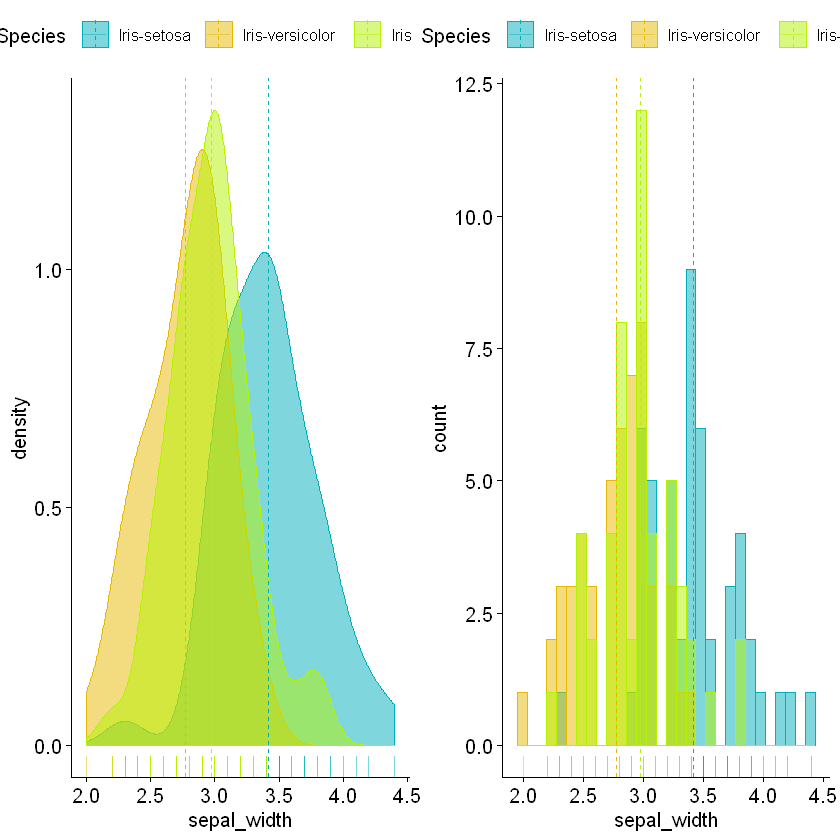

```r
# Graficas de Densidad e Histogramas plots usando ggpubr para la variable "sepal_width"

g1 <- ggdensity(dataSet, x = "sepal_width", add = "mean", rug = TRUE, color = "Species",
                fill = "Species", palette = c("#00AFBB", "#E7B800", "#B3F200"))

g2 <- gghistogram(dataSet, x = "sepal_width", add = "mean", rug = TRUE, color = "Species",
                  fill = "Species", palette = c("#00AFBB", "#E7B800", "#B3F200"))



grid.arrange(g1, g2, nrow = 1)
```

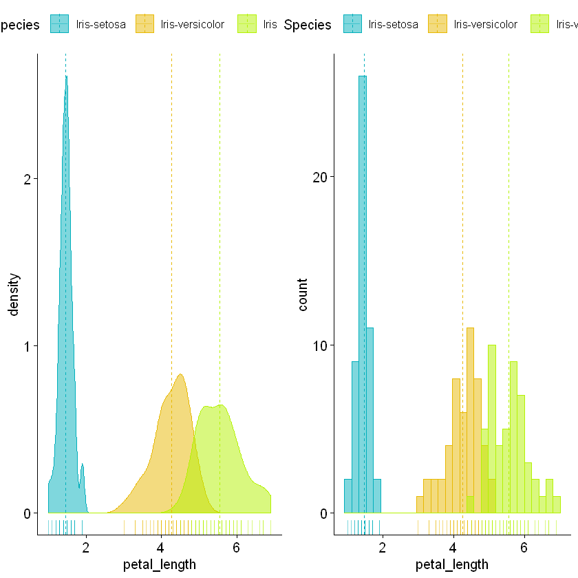

```r
# Graficas de Densidad e Histogramas plots usando ggpubr para la variable "petal_length"

g1 <- ggdensity(dataSet, x = "petal_length", add = "mean", rug = TRUE, color = "Species",
                fill = "Species", palette = c("#00AFBB", "#E7B800", "#B3F200"))

g2 <- gghistogram(dataSet, x = "petal_length", add = "mean", rug = TRUE, color = "Species",
                  fill = "Species", palette = c("#00AFBB", "#E7B800", "#B3F200"))




grid.arrange(g1, g2, nrow = 1)
```

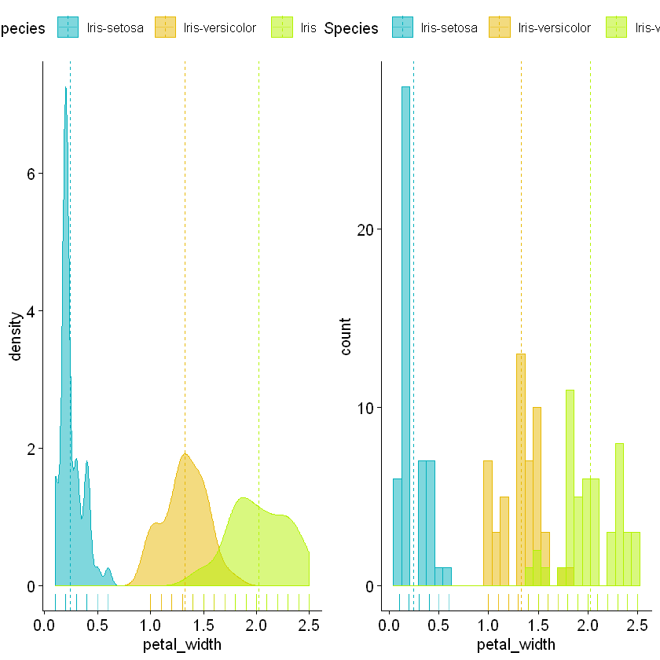

```r
# Graficas de Densidad e Histogramas plots usando ggpubr para la variable"petal_width"

g1 <- ggdensity(dataSet, x = "petal_width", add = "mean", rug = TRUE, color = "Species",
                fill = "Species", palette = c("#00AFBB", "#E7B800", "#B3F200"))

g2 <- gghistogram(dataSet, x = "petal_width", add = "mean", rug = TRUE, color = "Species",
                  fill = "Species", palette = c("#00AFBB", "#E7B800", "#B3F200"))



grid.arrange(g1, g2, nrow = 1)
```

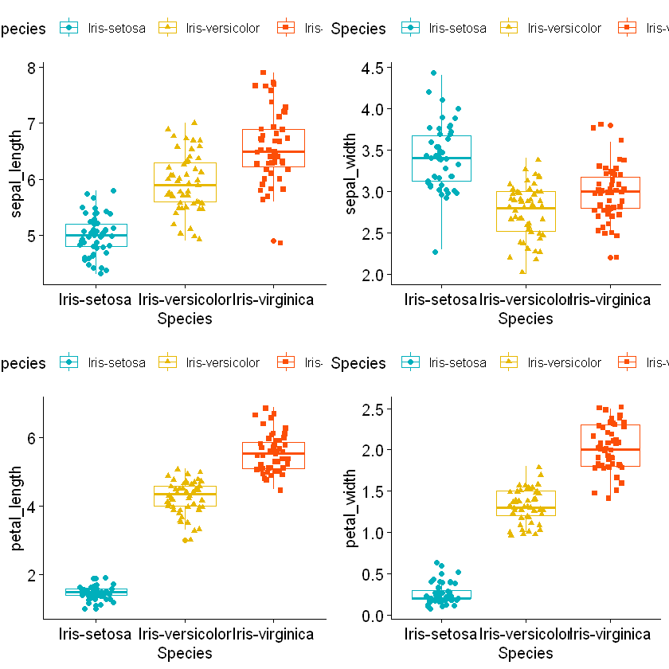

```r
# Diagramas de cajas usando ggpubr

Sepal_Length <- ggboxplot(dataSet, x = "Species", y = "sepal_length",
                          color = "Species", palette =c("#00AFBB", "#E7B800", "#FC4E07"),
                          add = "jitter", shape = "Species")

Sepal_Width <- ggboxplot(dataSet, x = "Species", y = "sepal_width",
                         color = "Species", palette =c("#00AFBB", "#E7B800", "#FC4E07"),
                         add = "jitter", shape = "Species")

Petal_Length <- ggboxplot(dataSet, x = "Species", y = "petal_length",
                          color = "Species", palette =c("#00AFBB", "#E7B800", "#FC4E07"),
                          add = "jitter", shape = "Species")

Petal_Width <- ggboxplot(dataSet, x = "Species", y = "petal_width",
                         color = "Species", palette =c("#00AFBB", "#E7B800", "#FC4E07"),
                         add = "jitter", shape = "Species")


grid.arrange(Sepal_Length,Sepal_Width,Petal_Length,Petal_Width, nrow=2)
```

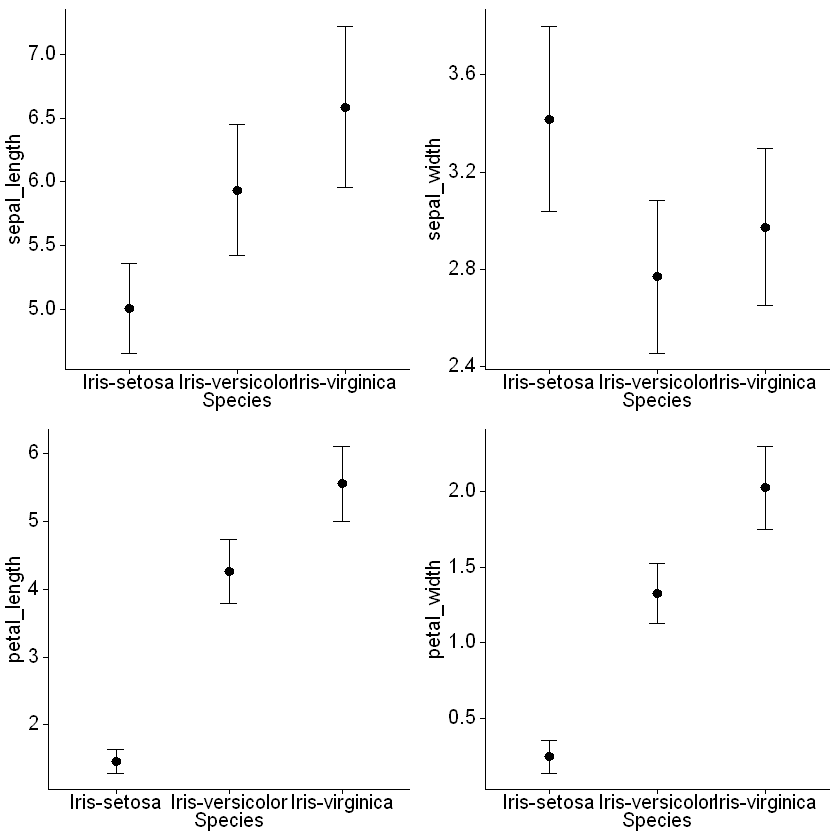

```r
# Grafica de Mean +/- standard deviation usando ggpubr

g1 <- ggerrorplot(dataSet, x = "Species", y = "sepal_length", desc_stat = "mean_sd",
                  error.plot = "errorbar",  add = "mean")

g2 <- ggerrorplot(dataSet, x = "Species", y = "sepal_width", desc_stat = "mean_sd",
                  error.plot = "errorbar",  add = "mean")

g3 <- ggerrorplot(dataSet, x = "Species", y = "petal_length", desc_stat = "mean_sd",
                  error.plot = "errorbar",  add = "mean")

g4 <- ggerrorplot(dataSet, x = "Species", y = "petal_width", desc_stat = "mean_sd",
                  error.plot = "errorbar",  add = "mean")

grid.arrange(g1, g2, g3, g4 , nrow=2)
```

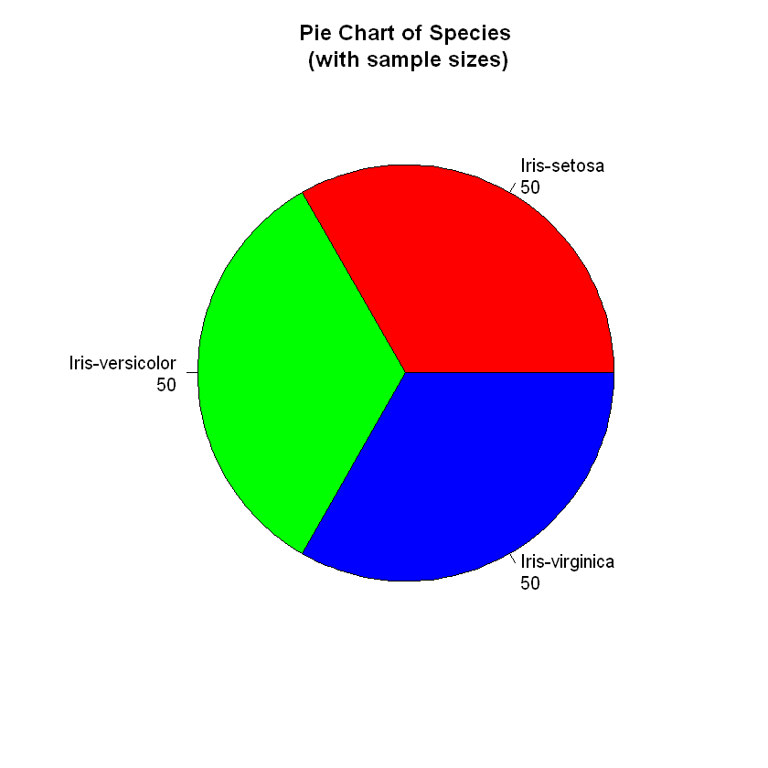

```r
# Grafica de Pie Chart

mytable <- table(dataSet$Species)

lbls <- paste(names(mytable), "\n", mytable, sep="")

pie(mytable, labels = lbls, col=rainbow(length(lbls)), main="Pie Chart of Species\n (with sample sizes)")
```

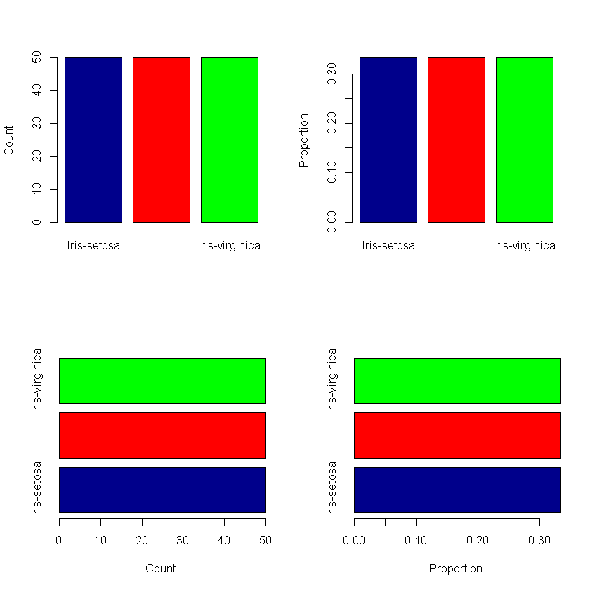

```r
# Barplot para datos categoricos

par(mfrow=c(2,2))

barplot(table(dataSet$Species), ylab = "Count",
        col=c("darkblue","red", "green"))
barplot(prop.table(table(dataSet$Species)), ylab = "Proportion",
        col=c("darkblue","red", "green"))

barplot(table(dataSet$Species), xlab = "Count", horiz = TRUE,
        col=c("darkblue","red", "green"))
barplot(prop.table(table(dataSet$Species)), xlab = "Proportion", horiz = TRUE,
        col=c("darkblue","red", "green"))
```

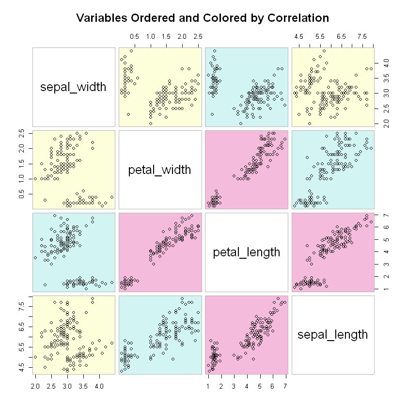

```r
# Matrices Scatterplot con el Package glus

library(gclus)
dta <- dataSet[c(1:4)]
dta.r <- abs(cor(dta))
dta.col <- dmat.color(dta.r)

# reordenar las variables para que las que tengan la mayor correlación estén más cerca de la diagonal
dta.o <- order.single(dta.r)
cpairs(dta, dta.o, panel.colors=dta.col, gap=.5, main="Variables Ordered and Colored by Correlation" )
```

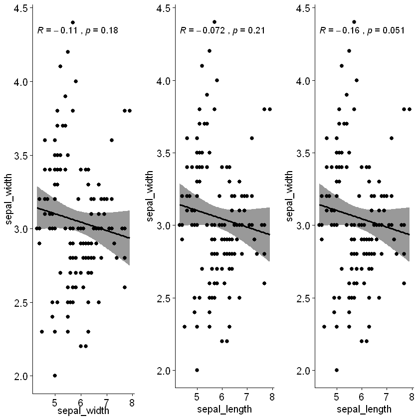

```r
# Visualizar Correlaciones usando ggpubr "SepalLength" vs "SepalWidth"

# Method 1: pearson
c1 <- ggscatter(dataSet, x = "sepal_length", y = "sepal_width",
                add = "reg.line", conf.int = TRUE,
                cor.coef = TRUE, cor.method = "pearson",
                xlab = "sepal_width", ylab = "sepal_width")


# Method 2: kendall
c2 <- ggscatter(dataSet, x = "sepal_length", y = "sepal_width",
                add = "reg.line", conf.int = TRUE,
                cor.coef = TRUE, cor.method = "kendall",
                xlab = "sepal_length", ylab = "sepal_width")


# Method 3: spearman
c3 <- ggscatter(dataSet, x = "sepal_length", y = "sepal_width",
                add = "reg.line", conf.int = TRUE,
                cor.coef = TRUE, cor.method = "spearman",
                xlab = "sepal_length", ylab = "sepal_width")

# plot
grid.arrange(c1,c2,c3, nrow=1)
```

```r
# Mas Graficas de correlaciones
# Using "Hmisc"

res2 <- rcorr(as.matrix(dataSet[,c(1:4)]))
# Extract the correlation coefficients
res2$r
# Extract p-values
res2$P
```

|  | sepal_length | sepal_width | petal_length | petal_width |
| --- | --- | --- | --- | --- |
| sepal_length | 1.0000000 | -0.1093692 | 0.8717542 | 0.8179536 |
| sepal_width | -0.1093692 | 1.0000000 | -0.4205161 | -0.3565441 |
| petal_length | 0.8717542 | -0.4205161 | 1.0000000 | 0.9627571 |
| petal_width | 0.8179536 | -0.3565441 | 0.9627571 | 1.0000000 |

|  | sepal_length | sepal_width | petal_length | petal_width |
| --- | --- | --- | --- | --- |
| sepal_length | NA | 1.827652e-01 | 0.000000e+00 | 0.000000e+00 |
| sepal_width | 0.1827652 | NA | 8.429366e-08 | 7.523891e-06 |
| petal_length | 0.0000000 | 8.429366e-08 | NA | 0.000000e+00 |
| petal_width | 0.0000000 | 7.523891e-06 | 0.000000e+00 | NA |

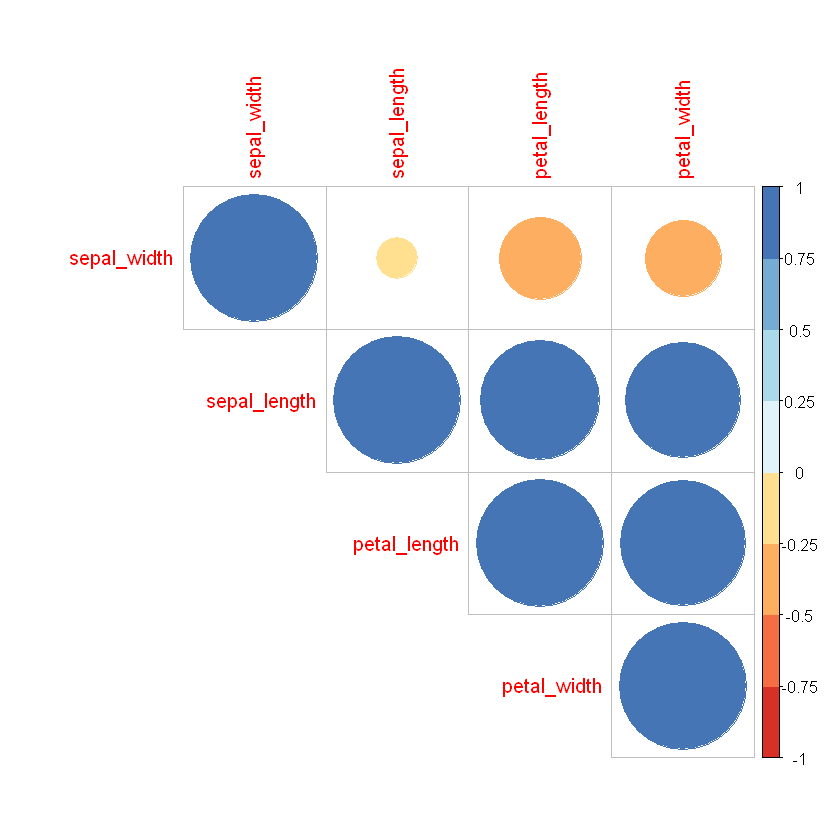

```r
# Usando la funcion cor

M <- cor(dataSet[,c(1:4)])
corrplot(M, type="upper", order="hclust", col=brewer.pal(n=8, name="RdYlBu"))
```

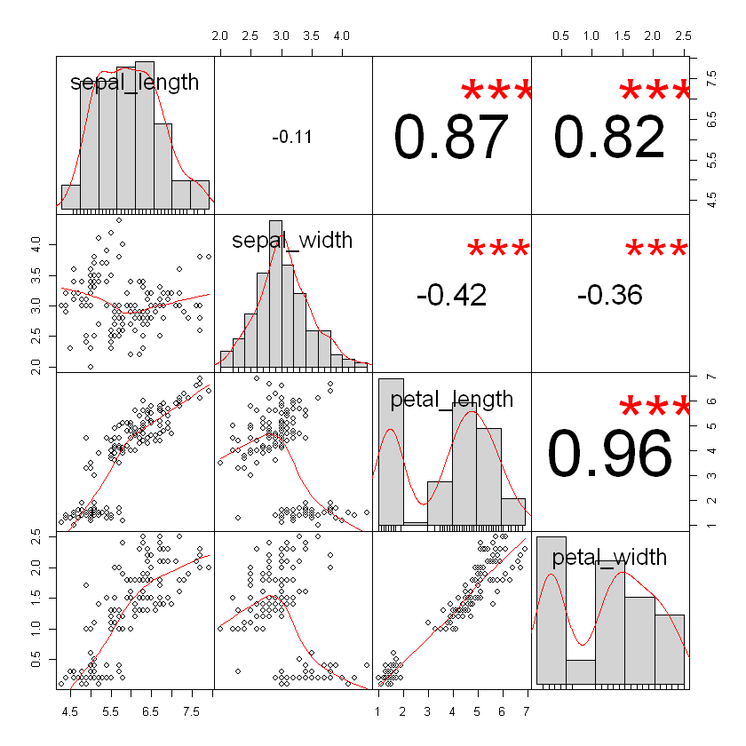

```r
# Usando PerformanceAnalytics
#install.packages("PerformanceAnalytics")

library(PerformanceAnalytics)
data <- dataSet[, c(1:4)]
chart.Correlation(data, histogram=TRUE, pch=19)
```

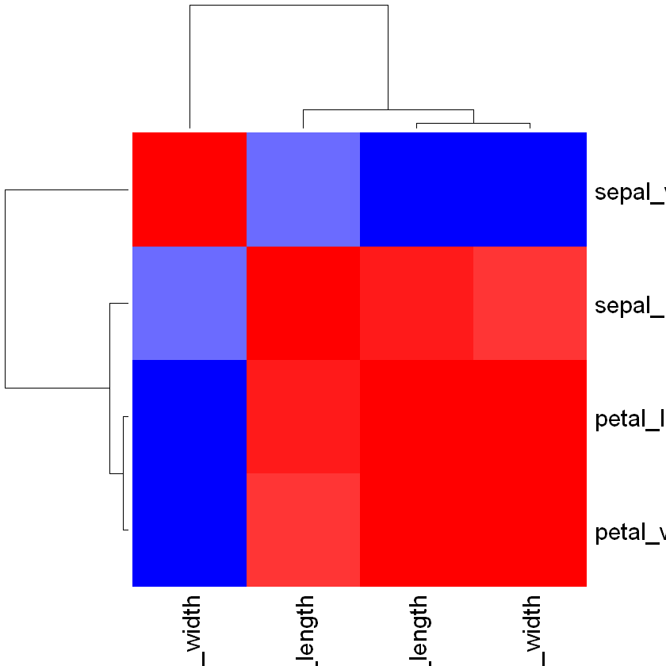

```r
# Usando Colored Headmap

par(mfrow=c(2,2))
col <- colorRampPalette(c("blue", "white", "red"))(20)
heatmap(x = res2$r, col = col, symm = TRUE)
```

```r
# ---------------------------------------------------
# Division de los datos
# ---------------------------------------------------

#para entrenamiento se usará el 75% de los datos

train_test_index <- createDataPartition(dataSet$Species, p=0.75, list=FALSE)
training_dataset <- dataSet[, c(1:5)][train_test_index,]
testing_dataset  <- dataSet[, c(1:5)][-train_test_index,]

dim(training_dataset)
dim(testing_dataset)
```

1. 114

2. 5

1. 36

2. 5

```r
# Proporcion de la variable respuesta en los datos de entrenamiento

prop.table(table(training_dataset$Species))
```

```
    Iris-setosa Iris-versicolor  Iris-virginica
      0.3333333       0.3333333       0.3333333
```

```r
# Proporcion de la variable respuesta en los datos de test

prop.table(table(testing_dataset$Species))
```

```
    Iris-setosa Iris-versicolor  Iris-virginica
      0.3333333       0.3333333       0.3333333
```

Para conseguir una estimación más certera, y antes de recurrir al conjunto de test, se pueden emplear estrategias de validación basadas en resampling. Cada uno funciona internamente de forma distinta, pero todos ellos se basan en la idea de ajustar y evaluar el modelo múltiples veces con distintos subconjuntos creados a partir de los datos de entrenamiento, obteniendo en cada repetición una estimación del error. El promedio de todas las estimaciones tiende a converger en el valor real del error de test.

Caret incorpora los métodos boot, boot632, optimism_boot, boot_all, cv, repeatedcv, LOOCV, LGOCV.

En este caso se recurre a **validación cruzada repetida** como método de validación.

number = Numero de particiones = 3

repeats = Numero de repeticiones = 3

Una validación cruzada con 3 particiones y 3 repeticiones, implica ajustar y evaluar el modelo 3 x 3 = 9 veces, cada vez con una partición distinta, más un último ajuste con todos los datos de entrenamiento para crear el modelo final.

El método predeterminado para optimizar los parámetros de ajuste trains usar una grid search. Este enfoque suele ser efectivo pero, en los casos en que hay muchos parámetros de ajuste, puede ser ineficiente. Hay varios modelos en los que esto puede ser beneficioso para encontrar valores razonables de los parámetros de ajuste en un tiempo relativamente corto. Sin embargo, hay algunos modelos donde la eficiencia en un campo de búsqueda pequeño puede cancelar otras optimizaciones. Para usar la búsqueda aleatoria, hay otra opción disponible en trainControl llamadas **search**. Los valores posibles de este argumento son **"grid"y "random"**. Los modelos incorporados en caret contienen código para generar combinaciones de parámetros de ajuste aleatorio. El número total de combinaciones únicas se especifica mediante la opción **tuneLength**.

```r
# -------------------------------------------------
# Validación cruzada y configuración de parámetros de control
# -------------------------------------------------

control <- trainControl(method="repeatedcv",
                        number = 3, repeats = 3,
                        verbose = TRUE, search = "grid",
                        allowParallel = TRUE)

metric <- "Accuracy"

tuneLength = 10
```

```r
# ------------------------------------------------- ---------------------
## 1. Entrenamiento - sin ajuste explícito de parámetros / usando el predeterminado
# --------------- -------------------------------------------------- -----
fit.LDA <- caret :: train ( Species ~ . , data = training_dataset , method = "lda" ,
                        metric = metric , trControl = control ,
                        verbose =  TRUE
)

print (fit.LDA )


fit.LDA2 <- caret :: train ( Species ~ . , data = training_dataset , method = "lda2" ,
                         metric = metric , trControl = control ,
                         verbose =  TRUE
)

print ( fit.LDA2 )
```

```
Linear Discriminant Analysis

114 samples
  4 predictor
  3 classes: 'Iris-setosa', 'Iris-versicolor', 'Iris-virginica'

No pre-processing
Resampling: Cross-Validated (3 fold, repeated 3 times)
Summary of sample sizes: 76, 76, 76, 75, 76, 77, ...
Resampling results:

  Accuracy   Kappa
  0.9793701  0.9690178

Linear Discriminant Analysis

114 samples
  4 predictor
  3 classes: 'Iris-setosa', 'Iris-versicolor', 'Iris-virginica'

No pre-processing
Resampling: Cross-Validated (3 fold, repeated 3 times)
Summary of sample sizes: 77, 76, 75, 75, 76, 77, ...
Resampling results across tuning parameters:

  dimen  Accuracy   Kappa
  1      0.9823731  0.9735207
  2      0.9677491  0.9515490

Accuracy was used to select the optimal model using the largest value.
The final value used for the model was dimen = 1.
```

```r
# ----------------------------------------------------------------------
## 2. Entrenamiento - con ajuste explícito de parámetros usando el método preProcess
# ----------------------------------------------------------------------
fit.LDA_preProc <- caret::train(Species~., data=training_dataset, method="lda",
                                metric=metric, trControl=control,
                                preProc=c("center", "scale", "pca", "expoTrans"),
                                verbose = TRUE
)
print(fit.LDA_preProc)

fit.LDA2_preProc <- caret::train(Species~., data=training_dataset, method="lda2",
                                 metric=metric, trControl=control,
                                 preProc=c("center", "scale", "pca", "expoTrans"),
                                 verbose = TRUE
)
print(fit.LDA2_preProc)
```

```
Linear Discriminant Analysis

114 samples
  4 predictor
  3 classes: 'Iris-setosa', 'Iris-versicolor', 'Iris-virginica'

Pre-processing: centered (4), scaled (4), principal component signal
 extraction (4), exponential transformation (4)
Resampling: Cross-Validated (3 fold, repeated 3 times)
Summary of sample sizes: 77, 76, 75, 78, 75, 75, ...
Resampling results:

  Accuracy   Kappa
  0.9300248  0.8949212

Linear Discriminant Analysis

114 samples
  4 predictor
  3 classes: 'Iris-setosa', 'Iris-versicolor', 'Iris-virginica'

Pre-processing: centered (4), scaled (4), principal component signal
 extraction (4), exponential transformation (4)
Resampling: Cross-Validated (3 fold, repeated 3 times)
Summary of sample sizes: 77, 76, 75, 76, 76, 76, ...
Resampling results across tuning parameters:

  dimen  Accuracy   Kappa
  1      0.9330322  0.8995063
  2      0.9358812  0.9037752

Accuracy was used to select the optimal model using the largest value.
The final value used for the model was dimen = 2.
```

```r
# -----------------------------------------------------------------------------
## 3. Entrenamiento - con ajuste explícito de parámetros usando el método preProcess
## & Automatic Grid i.e. tuneLength
# -----------------------------------------------------------------------------
fit.LDA_automaticGrid <- caret::train(Species~., data=training_dataset, method="lda",
                                      metric=metric, trControl=control,
                                      preProc=c("center", "scale", "pca", "expoTrans"),
                                      tuneLength = tuneLength,
                                      verbose = TRUE
)
print(fit.LDA_automaticGrid)

fit.LDA2_automaticGrid <- caret::train(Species~., data=training_dataset, method="lda2",
                                       metric=metric, trControl=control,
                                       preProc=c("center", "scale", "pca", "expoTrans"),
                                       tuneLength = tuneLength,
                                       verbose = TRUE
)
print(fit.LDA2_automaticGrid)
```

```
Linear Discriminant Analysis

114 samples
  4 predictor
  3 classes: 'Iris-setosa', 'Iris-versicolor', 'Iris-virginica'

Pre-processing: centered (4), scaled (4), principal component signal
 extraction (4), exponential transformation (4)
Resampling: Cross-Validated (3 fold, repeated 3 times)
Summary of sample sizes: 76, 76, 76, 75, 76, 77, ...
Resampling results:

  Accuracy   Kappa
  0.9267304  0.8900375

Linear Discriminant Analysis

114 samples
  4 predictor
  3 classes: 'Iris-setosa', 'Iris-versicolor', 'Iris-virginica'

Pre-processing: centered (4), scaled (4), principal component signal
 extraction (4), exponential transformation (4)
Resampling: Cross-Validated (3 fold, repeated 3 times)
Summary of sample sizes: 77, 75, 76, 77, 75, 76, ...
Resampling results across tuning parameters:

  dimen  Accuracy   Kappa
  1      0.9358691  0.9037897
  2      0.9300961  0.8951272

Accuracy was used to select the optimal model using the largest value.
The final value used for the model was dimen = 1.
```

```r
# -----------------------------------------------------------------------------
## 4. Entrenamiento - con ajuste explícito de parámetros usando el método preProcess
## & Manual Grid i.e. tuneGrid
# Grid necesita parametrizar manualmente para cada algoritmo particular
# -----------------------------------------------------------------------------

grid <- expand.grid(k=c(seq(from = 3, to = 10, by = 1)))


fit.LDA_manualGrid <- caret::train(Species~., data=training_dataset, method="loclda",
                                   metric=metric, trControl=control,
                                   preProc=c("center", "scale", "pca", "expoTrans"),
                                   tuneGrid = grid,
                                   verbose = TRUE
)
print(fit.LDA_manualGrid)

grid <- expand.grid(dimen=c(seq(from = 1, to = 10, by = 1)))
fit.LDA2_manualGrid <- caret::train(Species~., data=training_dataset, method="lda2",
                                    metric=metric, trControl=control,
                                    preProc=c("center", "scale", "pca", "expoTrans"),
                                    tuneGrid = grid,
                                    verbose = TRUE
)
print(fit.LDA2_manualGrid)
```

[output not shown]

[output cut: 25 more lines]

```

  dimen  Accuracy   Kappa
   1     0.9237861  0.8855972
   2     0.9180132  0.8769347
   3     0.9180132  0.8769347
   4     0.9180132  0.8769347
   5     0.9180132  0.8769347
   6     0.9180132  0.8769347
   7     0.9180132  0.8769347
   8     0.9180132  0.8769347
   9     0.9180132  0.8769347
  10     0.9180132  0.8769347

Accuracy was used to select the optimal model using the largest value.
The final value used for the model was dimen = 1.
```

```r
# ---------------------------------------
# recopilar los resultados de modelos entrenados
# ---------------------------------------
results <- resamples(list(trained_Model_1 = fit.LDA
                          , trained_Model_2 = fit.LDA2
                          , trained_Model_3 = fit.LDA_preProc
                          , trained_Model_4 = fit.LDA2_preProc
                          , trained_Model_5 = fit.LDA_automaticGrid
                          , trained_Model_6 = fit.LDA2_automaticGrid
                          , trained_Model_7 = fit.LDA_manualGrid
                          , trained_Model_8 = fit.LDA2_manualGrid
))


summary(results)
```

```
Call:
summary.resamples(object = results)

Models: trained_Model_1, trained_Model_2, trained_Model_3, trained_Model_4, trained_Model_5, trained_Model_6, trained_Model_7, trained_Model_8
Number of resamples: 9

Accuracy
                     Min.   1st Qu.    Median      Mean   3rd Qu.      Max.
trained_Model_1 0.9459459 0.9729730 0.9743590 0.9793701 1.0000000 1.0000000
trained_Model_2 0.9473684 0.9729730 0.9743590 0.9823731 1.0000000 1.0000000
trained_Model_3 0.8947368 0.9189189 0.9210526 0.9300248 0.9487179 0.9722222
trained_Model_4 0.8421053 0.8974359 0.9230769 0.9358812 1.0000000 1.0000000
trained_Model_5 0.8684211 0.8947368 0.9210526 0.9267304 0.9487179 0.9743590
trained_Model_6 0.8974359 0.9189189 0.9473684 0.9358691 0.9487179 0.9736842
trained_Model_7 0.8684211 0.8947368 0.9210526 0.9239766 0.9473684 0.9736842
trained_Model_8 0.8648649 0.8918919 0.9210526 0.9237861 0.9487179 0.9743590
                NA's
trained_Model_1    0
trained_Model_2    0
trained_Model_3    0
trained_Model_4    0
trained_Model_5    0
trained_Model_6    0
trained_Model_7    0
trained_Model_8    0

Kappa
                     Min.   1st Qu.    Median      Mean   3rd Qu.      Max.
trained_Model_1 0.9188596 0.9594298 0.9615385 0.9690178 1.0000000 1.0000000
trained_Model_2 0.9208333 0.9594298 0.9615385 0.9735207 1.0000000 1.0000000
trained_Model_3 0.8419958 0.8781559 0.8813736 0.8949212 0.9230769 0.9583333
trained_Model_4 0.7629938 0.8461538 0.8846154 0.9037752 1.0000000 1.0000000
trained_Model_5 0.8024948 0.8423237 0.8814969 0.8900375 0.9230769 0.9615385
trained_Model_6 0.8461538 0.8782895 0.9209979 0.9037897 0.9230769 0.9605400
trained_Model_7 0.8024948 0.8426501 0.8818653 0.8860677 0.9209979 0.9605400
trained_Model_8 0.7969265 0.8377193 0.8814969 0.8855972 0.9230769 0.9615385
                NA's
trained_Model_1    0
trained_Model_2    0
trained_Model_3    0
trained_Model_4    0
trained_Model_5    0
trained_Model_6    0
trained_Model_7    0
trained_Model_8    0
```

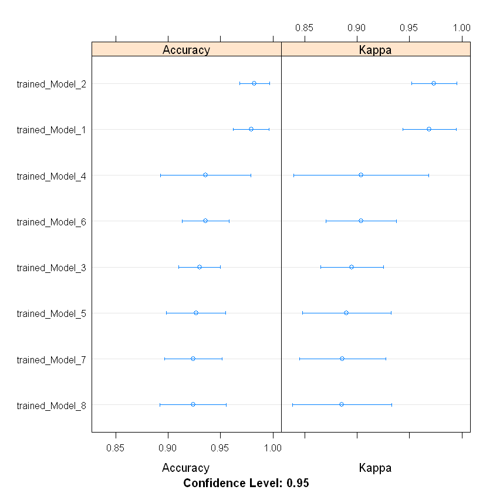

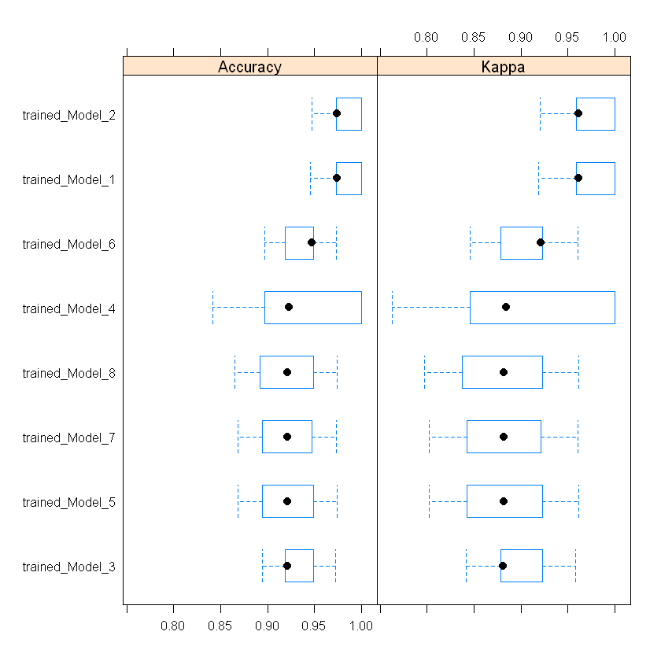

```r
# Grafica y rank de los modelos ajustados
dotplot(results)
bwplot(results)
```

```r
# asignar el modelo mejor entrenado basado en la precisión

best_trained_model <- fit.LDA2
```

```r
# ---------------------------------------------------------------------
# Test skill del modelo MEJOR entrenado en conjunto de datos de validación / prueba
# ---------------------------------------------------------------------
predictions <- predict(best_trained_model, newdata=testing_dataset)

# Evaluación del mejor modelo
res_  <- caret::confusionMatrix(predictions, testing_dataset$Species)

print("Results from the BEST trained model ... ...\n");

print(round(res_$overall, digits = 3))
```

```
[1] "Results from the BEST trained model ... ...\n"
      Accuracy          Kappa  AccuracyLower  AccuracyUpper   AccuracyNull
         0.944          0.917          0.813          0.993          0.333
AccuracyPValue  McnemarPValue
         0.000            NaN
```

```
Linear Discriminant Analysis

114 samples
  4 predictor
  3 classes: 'Iris-setosa', 'Iris-versicolor', 'Iris-virginica'

No pre-processing
Resampling: Cross-Validated (3 fold, repeated 3 times)
Summary of sample sizes: 77, 76, 75, 75, 76, 77, ...
Resampling results across tuning parameters:

  dimen  Accuracy   Kappa
  1      0.9823731  0.9735207
  2      0.9677491  0.9515490

Accuracy was used to select the optimal model using the largest value.
The final value used for the model was dimen = 1.
```

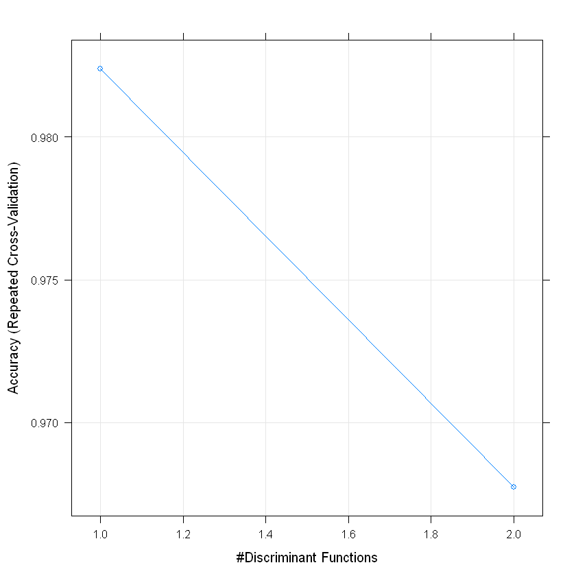

```r
print(best_trained_model)
plot(best_trained_model)
```

```r
# hacer predicciones sobre "nuevos datos" utilizando el modelo final

final_predictions <- predict(best_trained_model, dataSet[1:4])

confusionMatrix(final_predictions, dataSet$Species)

res_ <- confusionMatrix(final_predictions, dataSet$Species)

print("Results from the BEST trained model ... ...\n");

print(round(res_$overall, digits = 3))
```

```
Confusion Matrix and Statistics

                 Reference
Prediction        Iris-setosa Iris-versicolor Iris-virginica
  Iris-setosa              50               0              0
  Iris-versicolor           0              48              1
  Iris-virginica            0               2             49

Overall Statistics

               Accuracy : 0.98
                 95% CI : (0.9427, 0.9959)
    No Information Rate : 0.3333
    P-Value [Acc > NIR] : < 2.2e-16

                  Kappa : 0.97

 Mcnemar's Test P-Value : NA

Statistics by Class:

                     Class: Iris-setosa Class: Iris-versicolor
Sensitivity                      1.0000                 0.9600
Specificity                      1.0000                 0.9900
Pos Pred Value                   1.0000                 0.9796
Neg Pred Value                   1.0000                 0.9802
Prevalence                       0.3333                 0.3333
Detection Rate                   0.3333                 0.3200
Detection Prevalence             0.3333                 0.3267
Balanced Accuracy                1.0000                 0.9750
                     Class: Iris-virginica
Sensitivity                         0.9800
Specificity                         0.9800
Pos Pred Value                      0.9608
Neg Pred Value                      0.9899
Prevalence                          0.3333
Detection Rate                      0.3267
Detection Prevalence                0.3400
Balanced Accuracy                   0.9800
```

```
[1] "Results from the BEST trained model ... ...\n"
      Accuracy          Kappa  AccuracyLower  AccuracyUpper   AccuracyNull
         0.980          0.970          0.943          0.996          0.333
AccuracyPValue  McnemarPValue
         0.000            NaN
```